# Aula2: A complexidade na cidade

> “a cidade é a mais complexa das invenções humanas, (...) na confluência da natureza com o artefato” (LÉVI-STRAUSS, 1954, p. 137-138 apud MOUDON, 1997, p. 3)

## Último capítulo de Morte e Vida nas Grandes Cidades

- Jane Jacobs (1961), quem não leu?
- Qual o tipo de problema é a cidade?

*http://revistademorfologiaurbana.org/index.php/rmu/article/view/118/64*

## A Cidade não é uma árvore

- Cristopher Alexander (1961)
- Arquiteto, Urbanista e Matemático

*http://en.bp.ntu.edu.tw/wp-content/uploads/2011/12/06-Alexander-A-city-is-not-a-tree.pdf*

## Pequeno experimento matemático

- Teoria dos conjuntos

> Dado 100 pontos no espaço, quantas são as possibilidades de arranjos de conjuntos distintos?

$$ 2^{100} = 1,2676506×10^{30} $$

https://en.wikipedia.org/wiki/Orders_of_magnitude_(numbers)

## A Teoria da Complexidade de Edgar Morin

> "complexidade é um tecido (complexus: o que é tecido junto) de constituintes heterogêneas inseparavelmente associadas: ela coloca o paradoxo do uno e do múltiplo” (MORIN, 2015, p. 13)

> “O pensamento complexo não recusa de modo algum a clareza, a ordem, o determinismo. Ele os considera insuficiente, sabe que não se pode programar a descoberta, o conhecimento, nem a ação” (2015, p. 83)

*MORIN, Edgar. Introdução ao Pensamento Complexo. Porto Alegre: Sulina, 2015. 120 p.*

## Mas o que a complexidade tem haver com o Urbanismo?

> Cogito ergo sum (Penso logo existo)
- A simplicidade do planejamento urbano por variáveis simplistas e mono-dimensionais
- Moradia vs. Emprego
- A família heteronormativa
- A cidade compartimentada
- Diferente da matemática *os arranjos não precisam fazer sentido para todos*

## O Positivismo modernista e "o planejador" urbano

> O pressuposto que pode ser saber o que é melhor para o outro
- Ordem e progresso, definido por quem?
- Soluções impostas "top-down" sem diálogo, sem consenso, servindo a poucos ou a ninguém
- Higienismo, um fardo pesado

> Dica sobre o "positivsimo" brasileiro na proximodade dos 200 anos da "independência"
- https://piaui.folha.uol.com.br/materia/a-dependencia/
- https://projetoquerino.com.br/
- "A mulher da casa Abandonada" (com ressalvas)

## "...ismo" vs. "...logia"

- Emprestado do movimento LGBTQIA+

> O contrário de Urbanismo seria Ruralismo? Então por que não temos uma bancada Urbanista? Alias nem temos mais o Ministério das Cidades!

*http://seer.spo.ifsp.edu.br/index.php/regrasp/article/view/547/475*

| Modernismo/pós-modernismo | **_** |
| --- | --- |
| Impositivo | Consensual |
| Projetivo | Prescritivo |
| Orientado a desenho | Orientado à dados/código |
| Contemplativo | Descritivo |
| Causal consequencial | Modelos sistêmicos |
| Mapa se torna realidade | Realidade se torna mapa |
| Decisão Hierarquizada | Decisão Horizontalizada |
| Rigidez | Espontaneidade |
| Regras impositivas | Autonomia e responsividade |
| Monodisciplinar | Multidiscplinar |
| Escala local ou regional | Escala global |
| Homogenidade | Heterogenidade |
| Top-Down | Bottom-Up |
| Expectativas projetuais | Simulação Computacional |

> Parece que enquanto o "ismo" tenta impor um determinado modo de vida urbano, a "logia" tenta compreender aquilo que talvez ainda precisamos avançar muito.

> O primeiro passo para é talvez descrever o problema para começar a fazer sugestões ou até mesmo invenções.

## Concluindo Complexidade nas Cidades

- Parece que não temos vocação para enxergar a complexidade e problemas complexos como a cidade.
- Planos simplistas parecem convenientes e como, alguma coisa é melhor do que nada, nos apegamos.
- Mas existem métodos capazes de de nos auxiliar, sobretudo em um cenário de alta disponibilidade computacional.
- Identificar a similaridade e a diferença parece um bom começo e por isso, "...logia" ao invés de "...ismo"

## Modelando a complexidade

> Existem diversas estratégias para representar a complexidade da cidade
- Pode-se descrever a diversidade e dar nome à determinados padrões
- Pode-se representar redes e graphos e estuda-lo e quantifica-los
- Pode-se ainda criar modelos de processos decisórios múltiplos
- E ainda temos as técnicas de inteligência artificial e redes neurais entre outras

## A Complexidade pelas dimensões

- Dimensões perseptíveis (1D, 2D, 3D)
- Dimensões podem ser infinitas ou mesmo fracionárias, fractais
- Um modelo de 17 dimensões
- Agrupando pelas similaridades

## Algumas indicações de TEDs

- Mandelbrot: https://www.ted.com/talks/benoit_mandelbrot_fractals_and_the_art_of_roughness?language=pt&subtitle=pt
- Batty: https://www.youtube.com/watch?v=qO0h_oSwySw
- Geofrey West: https://www.youtube.com/watch?v=5e7-_WXg884 e https://www.ted.com/talks/geoffrey_west_the_surprising_math_of_cities_and_corporations?language=pt
- Mas só homem branco de idade avançada?
- Vandana Shiva: https://www.youtube.com/watch?v=ER5ZZk5atlE e https://www.academia.edu/6429132/Livro_vandana_shiva_monoculturas_da_mente
- Marilyn Vos Savant, a pessoa mais inteligente do mundo https://www.youtube.com/watch?v=dOQowCeAnRs
- Hanna Gadsby - Nanette https://www.netflix.com/br/title/80233611

> “A principal ameaça à vida em meio a diversidade deriva do hábito de pensarmos em termos de monoculturas, o que chamei de ‘monoculturas da mente’. As monoculturas da mente fazem a diversidade desaparecer da percepção e, consequentemente, do mundo. Adotar a diversidade como uma forma de pensar, como um contexto de ação, permite o surgimento de muitas opções”

Vandana Shina

- Mais um podcast https://www.radionovelo.com.br/tempoquente/

## Lição de Casa

A Terra é Plana! https://www.youtube.com/channel/UCQd6D5f2IylFDdr0cCIREYQ

> É mentira! A lição e também que a Terra é Plana, Redonda, Esférica ou até mesmo Elipsoide em alguns casos

## Que tal praticar um pouco?

- O cadastro de IPTU
- Como funciona o IPTU? CAdastro Multifinalitário, SQL, dados.

> Pode ter certeza, toda cidade tem, e vc tem o direito de obter esses dados, ainda vamos falar sobre dados abertos

## Por que usar uma linguagem de programação?

> Lembram que o estímulo visual pode nos tornar cegos? Lembram todo aquele papo de pedagogia, era para estimular algumas e alguns de vcs a começarem programar :)
- Documentar, persistir e compartilhar o processo
- BigData, computação em nuvem, infraestrutura computacional
- Diálogo em equipes, ainda vamos falar disso
- Afinal, um dia você não sabia usar Planilhas
- Mas calma, isso não é um tutorial. É Freiriano esse método

```python
# Importanto uma biblioteca externa
import pandas as pd
```

```python
# Carregando os dados de IPTU de 2020
# e atribuindo o valor a uma variável
df_iptu = pd.read_csv('IPTU/IPTU_2022.zip', compression='zip', encoding='iso-8859-9', sep=';', decimal=',')
```

```python
df_iptu.shape
```

[output not shown]

```python
# Mostrando o conteudo da variável criada
df_iptu
```

|  | NUMERO DO CONTRIBUINTE | ANO DO EXERCICIO | NUMERO DA NL | DATA DO CADASTRAMENTO | TIPO DE CONTRIBUINTE 1 | CPF/CNPJ DO CONTRIBUINTE 1 | NOME DO CONTRIBUINTE 1 | TIPO DE CONTRIBUINTE 2 | CPF/CNPJ DO CONTRIBUINTE 2 | NOME DO CONTRIBUINTE 2 | ... | ANO DA CONSTRUCAO CORRIGIDO | QUANTIDADE DE PAVIMENTOS | TESTADA PARA CALCULO | TIPO DE USO DO IMOVEL | TIPO DE PADRAO DA CONSTRUCAO | TIPO DE TERRENO | FATOR DE OBSOLESCENCIA | ANO DE INICIO DA VIDA DO CONTRIBUINTE | MES DE INICIO DA VIDA DO CONTRIBUINTE | FASE DO CONTRIBUINTE |
| --- | --- | --- | --- | --- | --- | --- | --- | --- | --- | --- | --- | --- | --- | --- | --- | --- | --- | --- | --- | --- | --- |
| 0 | 0010030001-4 | 2020 | 1 | 11/01/20 | PESSOA FISICA (CPF) | XXXXXX0214XXXX | MARCIO MOURCHED | NaN |  | NaN | ... | 1924 | 1 | 13.00 | Loja | Comercial horizontal - padrão B | De esquina | 0.2 | 1963 | 1 | 0 |
| 1 | 0010030002-2 | 2020 | 1 | 11/01/20 | PESSOA FISICA (CPF) | XXXXXX0214XXXX | MARCIO MOURCHED | NaN |  | NaN | ... | 1944 | 1 | 6.00 | Loja | Comercial horizontal - padrão B | Normal | 0.2 | 1963 | 1 | 0 |
| 2 | 0010030003-0 | 2020 | 1 | 11/01/20 | PESSOA FISICA (CPF) | XXXXXX0214XXXX | MARCIO MOURCHED | NaN |  | NaN | ... | 1965 | 2 | 7.85 | Loja | Comercial horizontal - padrão B | Normal | 0.3 | 1963 | 1 | 0 |
| 3 | 0010030004-9 | 2020 | 1 | 11/01/20 | PESSOA FISICA (CPF) | XXXXXX2094XXXX | AUGUSTO CESAR DE MATTOS JUNIOR | NaN |  | NaN | ... | 1944 | 1 | 6.05 | Loja | Comercial horizontal - padrão B | Normal | 0.2 | 1963 | 1 | 0 |
| 4 | 0010030005-7 | 2020 | 1 | 11/01/20 | PESSOA FISICA (CPF) | XXXXXX2094XXXX | AUGUSTO CESAR DE MATTOS JUNIOR | NaN |  | NaN | ... | 1944 | 1 | 6.70 | Loja | Comercial horizontal - padrão B | Normal | 0.2 | 1963 | 1 | 0 |
| ... | ... | ... | ... | ... | ... | ... | ... | ... | ... | ... | ... | ... | ... | ... | ... | ... | ... | ... | ... | ... | ... |
| 3498639 | 3101180238-1 | 2020 | 1 | 11/01/20 | PESSOA FISICA (CPF) | XXXXXX5127XXXX | CECILIA OTUKA | NaN |  | NaN | ... | 1978 | 5 | 0.00 | Apartamento em condomínio | Residencial vertical - padrão B | De esquina | 0.2 | 1985 | 1 | 0 |
| 3498640 | 3101180239-1 | 2020 | 1 | 11/01/20 | PESSOA FISICA (CPF) | XXXXXX6436XXXX | JOSE ESTANISLAU CAMPOS MACHADO FILHO | NaN |  | NaN | ... | 1978 | 5 | 0.00 | Apartamento em condomínio | Residencial vertical - padrão B | De esquina | 0.2 | 1985 | 1 | 0 |
| 3498641 | 3101180240-3 | 2020 | 1 | 11/01/20 | PESSOA FISICA (CPF) | XXXXXX6473XXXX | DOUGLAS MACEDO | PESSOA FISICA (CPF) | XXXXXX9655XXXX | JOICE FERNANDA PAIXAO MACEDO | ... | 1978 | 5 | 0.00 | Apartamento em condomínio | Residencial vertical - padrão B | De esquina | 0.2 | 1985 | 1 | 0 |
| 3498642 | 3101190001-4 | 2020 | 1 | 11/01/20 | PESSOA JURIDICA (CNPJ) | XXXXXXXXXXXXXX | ESTADO DE SAO PAULO | NaN |  | NaN | ... | 0 | 0 | 0.00 | Terreno | TERRENO | De esquina | 0.0 | 1988 | 1 | 0 |
| 3498643 | 3101200001-7 | 2020 | 1 | 11/01/20 | PESSOA JURIDICA (CNPJ) | XXXXXXXXXXXXXX | ESTADO DE SAO PAULO | NaN |  | NaN | ... | 0 | 0 | 500.00 | Terreno | TERRENO | Normal | 0.0 | 1988 | 1 | 0 |

3498644 rows × 35 columns

```python
# Quantas linhas tem o cadastro de IPTU?
len(df_iptu)
```

```
3498644
```

```python
# Quantas e quais as colunas tem o cadastro?
df_iptu.columns
```

```
Index(['NUMERO DO CONTRIBUINTE', 'ANO DO EXERCICIO', 'NUMERO DA NL',
       'DATA DO CADASTRAMENTO', 'TIPO DE CONTRIBUINTE 1',
       'CPF/CNPJ DO CONTRIBUINTE 1', 'NOME DO CONTRIBUINTE 1',
       'TIPO DE CONTRIBUINTE 2', 'CPF/CNPJ DO CONTRIBUINTE 2',
       'NOME DO CONTRIBUINTE 2', 'NUMERO DO CONDOMINIO', 'CODLOG DO IMOVEL',
       'NOME DE LOGRADOURO DO IMOVEL', 'NUMERO DO IMOVEL',
       'COMPLEMENTO DO IMOVEL', 'BAIRRO DO IMOVEL', 'REFERENCIA DO IMOVEL',
       'CEP DO IMOVEL', 'QUANTIDADE DE ESQUINAS/FRENTES', 'FRACAO IDEAL',
       'AREA DO TERRENO', 'AREA CONSTRUIDA', 'AREA OCUPADA',
       'VALOR DO M2 DO TERRENO', 'VALOR DO M2 DE CONSTRUCAO',
       'ANO DA CONSTRUCAO CORRIGIDO', 'QUANTIDADE DE PAVIMENTOS',
       'TESTADA PARA CALCULO', 'TIPO DE USO DO IMOVEL',
       'TIPO DE PADRAO DA CONSTRUCAO', 'TIPO DE TERRENO',
       'FATOR DE OBSOLESCENCIA', 'ANO DE INICIO DA VIDA DO CONTRIBUINTE',
       'MES DE INICIO DA VIDA DO CONTRIBUINTE', 'FASE DO CONTRIBUINTE'],
      dtype='object')
```

```python
# Obtendo dados somente de uma coluna
quantidade_pavimentos = df_iptu.loc[:, ['QUANTIDADE DE PAVIMENTOS']]
quantidade_pavimentos
```

|  | QUANTIDADE DE PAVIMENTOS |
| --- | --- |
| 0 | 1 |
| 1 | 1 |
| 2 | 2 |
| 3 | 1 |
| 4 | 1 |
| ... | ... |
| 3498639 | 5 |
| 3498640 | 5 |
| 3498641 | 5 |
| 3498642 | 0 |
| 3498643 | 0 |

3498644 rows × 1 columns

```python
# Agrupando a quantidade de pavimentos
quantidade_pavimentos.value_counts()
```

```
QUANTIDADE DE PAVIMENTOS
2                           787414
1                           745087
5                           136667
14                          123194
9                           113328
0                           109885
17                          106278
15                          102207
16                          101663
13                          101474
19                           94258
18                           92725
4                            89182
11                           75101
```

[output cut: 36 more lines]

```python
# Ordenando os valores
quantidade_pavimentos.value_counts().sort_index()
```

```
QUANTIDADE DE PAVIMENTOS
0                           109885
1                           745087
2                           787414
3                            69170
4                            89182
5                           136667
6                            14307
7                            18087
8                            34137
9                           113328
10                           54057
11                           75101
12                           73939
13                          101474
```

[output cut: 36 more lines]

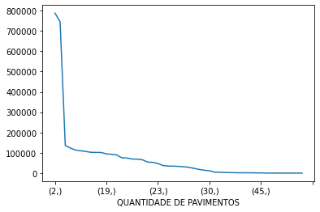

```python
# Visualizando os dados
quantidade_pavimentos.value_counts().plot()
```

[output not shown]

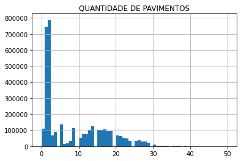

```python
# Mas e se quisermos o histograma
quantidade_pavimentos.hist(bins=60)
```

```python
# Existem mais "contribuintes" em apartamento ou em casas
# o que é apartamento e o que é casa?
# ALERTA: aqui já é algo mais avançado não se preocupe se não entender, concentre-se na possibilidade e não na repetição

limite_pavimentos = 3

def apartamento_ou_casa(quantidade):
    if quantidade > limite_pavimentos:
        return "apartamento"
    else:
        return "casa"

quantidade_pavimentos['QUANTIDADE DE PAVIMENTOS'].apply(apartamento_ou_casa)
```

```
0                 casa
1                 casa
2                 casa
3                 casa
4                 casa
              ...
3498639    apartamento
3498640    apartamento
3498641    apartamento
3498642           casa
3498643           casa
Name: QUANTIDADE DE PAVIMENTOS, Length: 3498644, dtype: object
```

```python
quantidade_pavimentos['QUANTIDADE DE PAVIMENTOS'].apply(apartamento_ou_casa).value_counts()
```

```
apartamento    1787088
casa           1711556
Name: QUANTIDADE DE PAVIMENTOS, dtype: int64
```

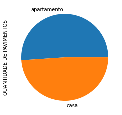

```python
quantidade_pavimentos['QUANTIDADE DE PAVIMENTOS'].apply(apartamento_ou_casa).value_counts().plot.pie()
```

```python
# O que mais?
```

## Pra quem quiser aprender a fazer e não saber só das possibilidades

- SUPER DICA -> Canal Programação Dinâmica no YouTube https://www.youtube.com/c/Programa%C3%A7%C3%A3oDin%C3%A2mica
- Playlist de Ciência de Dados
- https://www.casadocodigo.com.br/products/livro-pandas-python
- https://www.amazon.com.br/Python-Para-An%C3%A1lise-Dados-Tratamento/dp/8575226479/ref=pd_bxgy_img_1/130-5147197-8870527?pd_rd_w=JU5I8&pf_rd_p=4a943320-02ab-4775-ad7a-eaf57d00a244&pf_rd_r=EVKT9ZA0TN6PAKP6XY4B&pd_rd_r=016fe1ab-3a04-4523-b3b2-a531153d997a&pd_rd_wg=IuPfI&pd_rd_i=8575226479&psc=1
- https://github.com/geoinfo-smdu/

> Mas também existem outras possibilidade de análise de grandes volumes de dados com R ou mesmo outras linguagens de programação, SPSS, Matlab, etc ...